# Nine strategies for legitimising implementation

In the context of prioritising buses and trams

James Reynolds

2026-07-13

A two-page A4 printer-friendly version of this document is available at https://tinyurl.com/3v2u935r

Why is improving systems, such as transport, *so hard?* How can measures that are known to improve things by researchers, scientists, engineers and other technical specialists, but that are potentially publically *unpopular or politically controversial* be successfully implemented?

Such as bus or bike lanes, pedestrian malls or road pricing. Or, more generally, meaningful action on climate change, vacination programs or … (insert your issue here).

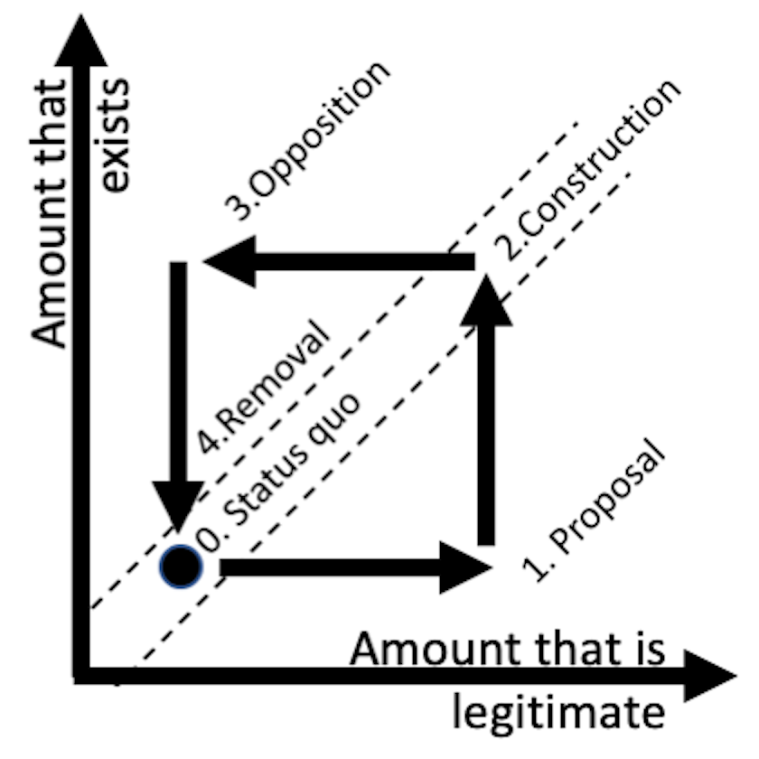

Figure 1: Legitimacy framework and a simple progression. Source: Author.

This page outlines a new framework (Figure 1) and nine pragmatic strategies, which may help you improve transport or other systems in the real-world of politics, *NIMBYism* and other non-technical challenges. These strategies involve:

- (A1-3) building legitimacy *before* implementation;
- (B1-3) avoiding impacts; and
- (C1-3) building legitimacy *through* implementation.

Legitimacy comes in many forms, and what is considered legitimate might vary with time or by arena. For example, installing a bus or bike lane might be identified as the ‘best’ option in a engineering or planning department, yet be considered unreasonable by drivers, business owners or the local council.

e.g. normative, sociological, through trust, through reasonableness, through unconditional duty, through public consent, or associated with conditional normative support.

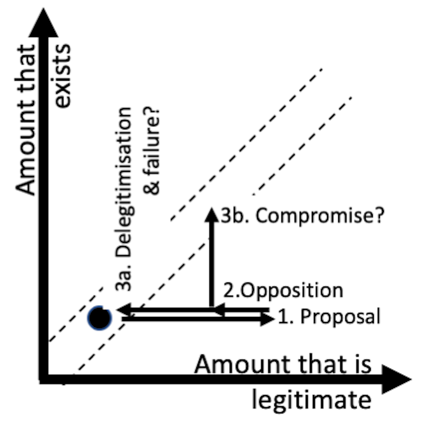

Figure 2: Progressions involving opposition, failure or compromise. Source: Author.

The simple progression shown in Figure 1 indicates an improvement being proposed, legitimised and built, but then opposed, delegitimised and removed. Figure 2 shows other how other progressions might instead lead to rejection of a proposal entirely or a compromise. For example, a bus lane might be warranted, but opposition might lead to no change from the status quo or a compromise High Occupancy Vehicle (HOV) lane instead.

But how to make progress? The research described here examined cases of successful and not-as-successful pedestrian malls, bicycle lanes and transit priority measures across Curitiba, Zürich, Boston, Toronto and Melbourne. Findings are published as Reynolds and Currie (2021) and Reynolds (2020), but details of the pragmatic strategies are briefly described in the following.

Reynolds, James, and Graham Currie. 2021. “New Approaches and Insights to Managing on-Road Public Transport Priority.” Chap. 10 in *Handbook of Public Transport Research*, edited by Graham Currie. Edward Elgar Publishing Limited.

Reynolds, James. 2020. “A Framework and Pragmatic Strategies for Transit Priority Implementation.” PhD. PhD thesis, Monash University. https://doi.org/10.26180/13377680.v1.

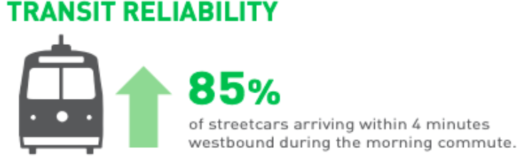

Figure 3: King Street Pilot dashbouard (excerpt). Source: City of Toronto and Toronto Transit Commission (2018).

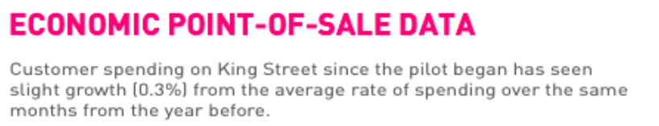

Figure 3: King Street Pilot dashbouard (excerpt). Source: City of Toronto and Toronto Transit Commission (2018).

Building legitimacy before implementation might involve *(A1) technical evaluation and reporting*, which is a common engineering, planning and policy-making activity. However, here it is suggested that this be focused towards other, non-technical, policy arenas as the people you will likely need to convince are probably politicians, members of the general public or others who are not within your branch of the Science, Technology, Engineering, Mathematics (STEM) and related fields. Figure 3 shows an example from Toronto, where monthly dashboards during the King Street Transit Pilot showed data on transit performance, traffic impacts and changes to economic activity in a format tailored for public consumption.

An *(A2) vision-led plan* might also be used, along the same lines as “disjointed incrementalism” (Lindblom 1979). For example, Curitiba’s famous Bus Rapid Transit (BRT) network was supported by a 1960s plan for transport and land-use to develop along linear ‘Structural Axes’. It was not until the 1990s that plans for these to eventually become Light Rail Transit (LRTs) were abandoned (Ardila-Gómez 2004), once the famous *bus boarding tubes* had been developed and proved to be a successful and lower-cost option for increasing capacity. Similarly, the Citizens’ Transit Priority Initiative in Zürich called for buses and trams to “travel along their lanes or tracks virtually as fast as is technically possible”(Nash and Sylvia 2001). A counter-example is provided by the partially-removed Stud Road bus lanes in Melbourne. There the supporting transport plan set bus lanes as a specific objective. Following an election, the bus lanes were removed (in some places) in fulfillment of a political promise(Bernecich 2011). A more flexible vision of doing whatever could be done to increase bus speeds and reliability might have allowed for alternative (non-bus lane) measures to be tried instead, especially in locations where bus lanes where particularly unpopular.

Lindblom, Charles E. 1979. “Still Muddling, Not yet Through.” *Public Administration Review* 39 (6): 517–26. https://doi.org/10.2307/976178.

Ardila-Gómez, Arturo. 2004. “Transit Planning in Curitiba and Bogotá: Roles in Interaction, Risk, and Change.” PhD thesis, Massachusetts Institute of Technology, Department of Urban Studies; Planning.

See https://tinyurl.com/4pcr9r45

Nash, Andrew, and Ronald Sylvia. 2001. *Implementation of Zürich’s Transit Priority Program*. Mineta Transportation Institute, San José State University.

Bernecich, Adrian. 2011. “Bus Lanes Returned to Cars.” *Knox Leader*.

*(A3) Public processes* might also be used to build legitimacy. This was the case in Zürich where the Citizens’ Transit Priority Initiative was passed in a public ballot (Nash and Sylvia 2001), providing legitimacy through public consent. Direct democracy deciding transport policy appears rare, but the research found cases where council meetings, hearings, elections and other public processes helped legitimise implementation.

Nash, Andrew, and Ronald Sylvia. 2001. *Implementation of Zürich’s Transit Priority Program*. Mineta Transportation Institute, San José State University.

But why not simply *avoid impacting* those who might oppose implementation? This approach was successful for the Eglinton Crosstown LRT in Toronto, some of which is *(B1) grade-separated (going under)* so as not to impact traffic. In the context of a narrow road corridor and Mayor Rob Ford’s declaration that “the war on the car is over”(Kalinowski and Rider 2010), going underground (even though very expensive) appears to have been the only way to get the LRT. Similarly, the Stud Road bus lanes were only removed where they had been converted from a traffic lane. Parts where they had been built as *(B2) additional capacity (going around)* through road widening remain in place to this day. *(B3) Subservient priority* similarly seeks to limit opposition by doing everything that can be done to help transit, but without impacting motorists. This is the genesis of Curibita’s famous tubular bus stops and helps explains the retention of hook turns in Clarendon Street in Melbourne.

Kalinowski, Tess, and David Rider. 2010. “’War on the Car Is over’: Ford Moves Transit Underground.” *The Star (Toronto)* (Toronto, Ontario).

First introduced on new ‘direct bus’ services running in mixed traffic, rather than along the busways. These decreased dwell time, so as to increase frequency and therefore capacity, but did not impact on other road users.

Far side stops in Clarendon Street were removed after opposition from local businesses. However, the hook turns installed in the pilot project did not impact on-street parking, and hence were able to be retained.

Legitimacy *THROUGH* IMPLEMENTATION relates to the idea that “if they had a chance to actually see it, everyone would love it”. With *(C1) Bottom-up and Incremental* implementation successive small changes are made, seeking to build on initial successes. The gradual addition of tram separation kerbing in central Melbourne over recent decades provides an example. Others are evident in Curitiba where: the central pedestrian mall gradually expanded; one Structural Axis eventually became three; and tubular bus stops were gradually introduced across the network. *(C2) Pop-ups* and *(C3) Trials* provide other real-world demonstrations, without an initial commitment to permanence. Curitiba’s pedestrian mall (initially a pop-up), the King Street Transit Pilot, guerrilla bike lanes in Seattle (Fucoloro 2013) and pop-up bus lanes in Boston and elsewhere provide example of this approach, which is also common in tactical urbanism (Lydon and Garcia 2015).

Attributed to Curitiba’s Mayor, Jamie Lerner by Bill McKibben (2007) in *Hope, human and wild: true stories of living lightly on the earth*.

Sometimes during track renewal works. In other cases tram priority measures have been included as part of works to make stops level-boarding accessible.

Fucoloro, Tom. 2013. “Guerrilla Road Safety Group ’Politely’ Installs Illegal Bike Lane Protectors on Cherry Street.” *Seattle Bike Blog* (Seattle, Washigton, USA).

Lydon, Mike, and Anthony Garcia. 2015. *Tactical Urbanism : Short-Term Action for Long-Term Change*. Island Press.

Standards; analysis; planning, scientific and engineering activity might help determine what is technically appropriate or ‘good’ policy. But, such techno-rational thinking is not necessarily key to transport or other policy-making(Marsden and Reardon 2017).

Marsden, Greg, and Louise Reardon. 2017. “Questions of Governance: Rethinking the Study of Transportation Policy.” *Transportation Research Part A: Policy and Practice* 101: 238–51. https://doi.org/10.1016/j.tra.2017.05.008.

These nine strategies, sometimes individually, often together, have worked in Boston, Curitiba, Melbourne, Toronto, Zürich and elsewhere. They suggest ways to improve transport in the context of institutions, public support (or the lack of it), politics and other factors.

Perhaps (A1-3) legitimisation *before* implementation, (B1-3) *avoiding impacts*, (C1-3) legitimisation *through* implementation and the framework may be useful in your attempts to successfully achieve (technically-appropriate) change. Good luck!

See further research at https://orcid.org/0000-0002-5508-9810]